# Practice 7.4

Annie

2024-11-12

Practice 7.4 Create your own pearson.test function (e.g. you will not use the above cor.test function but you will code your own function). The function should (at least) be able to test for the correlation between two variables. You will need to check at ?pt (or similar function) in order to extract the p-value. You can “dissect” the code source of the current cor.test function using getAnywhere(“cor.test.default”). Using the rairuoho dataset, please use your customized function to test correlation between length at day 3 & day 4 then day 3 & day 8 in each treatment (nutrient and water). Interpret results

?pt 是用來查詢 pt 函數的說明文件。pt 是一個內建函數，用於計算 t 分佈的累積分佈函數 (CDF, cumulative distribution function)。pt 是 t 分佈的累積分佈函數，常用於計算： 單尾或雙尾的 p 值。 給定 t 值及自由度時，對應的累積概率。

```r
library(ggplot2)


pearson.test <- function(x, y) {
  n <- length(x) # 樣本數
  if (n != length(y)) {
    stop("The lengths of the two variables must match.")
  }
  r <- cor(x, y, method = "pearson")
  t_value <- r * sqrt((n - 2) / (1 - r^2))
  p_value <- 2 * pt(-abs(t_value), df = n - 2)
  return(list(correlation = r, t_value = t_value, p_value = p_value))
}

nutrient <- subset(rairuoho, treatment == "nutrient")
water <- subset(rairuoho, treatment == "water")


nutrient34 <- pearson.test(nutrient$day3, nutrient$day4)
nutrient38 <- pearson.test(nutrient$day3, nutrient$day8)


water34 <- pearson.test(water$day3, water$day4)
water38 <- pearson.test(water$day3, water$day8)


nutrient34
```

```
## $correlation
## [1] 0.774425
##
## $t_value
## [1] 5.741382
##
## $p_value
## [1] 8.93837e-06
```

```r
nutrient38
```

```
## $correlation
## [1] 0.2416871
##
## $t_value
## [1] 1.168247
##
## $p_value
## [1] 0.2552119
```

```r
water34
```

```
## $correlation
## [1] 0.7864562
##
## $t_value
## [1] 5.972364
##
## $p_value
## [1] 5.197822e-06
```

```r
water38
```

```
## $correlation
## [1] 0.4595545
##
## $t_value
## [1] 2.426958
##
## $p_value
## [1] 0.02386844
```

Nutrient Treatment (Day 3 vs Day 4):

Correlation coefficient: 0.774425 → a strong positive correlation between Day 3 and Day 4.

p-value: 8.93837e-06 much smaller than 0.05→there is a significant positive correlation between Day 3 and Day 4

Water Treatment (Day 3 vs Day 4):

Correlation coefficient: 0.7865 strong positive correlation between Day 3 and Day 4

p-value: 5.197822e-06 extremely small→ there is a significant positive correlation between Day 3 and Day 4

Nutrient Treatment Results (Day 3 vs Day 8):

Correlation coefficient: 0.2417 The correlation is quite low,→little linear relationship between length at Day 3 and Day 8 data under the nutrient treatment.

t-value: 1.168247 The t-value is not very high→low correlation.

p-value: 0.2552119 Since this p-value is > 0.05→ no significant correlation.

Water Treatment Results (Day 3 vs Day 8):

Correlation coefficient: 0.4595545 a moderate linear relationship between Day 3 and Day 8 data under the water treatment.

t-value: 2.426958 The t-value is higher→moderate correlation.

p-value: 0.02386844 <0.05→correlation is statistically significant.

Summary: • Day 3 and Day 4 show significant positive correlations in both nutrient and water treatments, indicating a strong linear relationship between the lengths on these two days. • Day 3 and Day 8 show no significant correlation in the nutrient treatment (p-value > 0.05), but a moderate positive correlation in the water treatment (p-value < 0.05). •  
Thus, length in Day 3 and Day 4 have a significant correlation in both treatments, while the correlation between Day 3 and Day 8 is weaker or not significant.

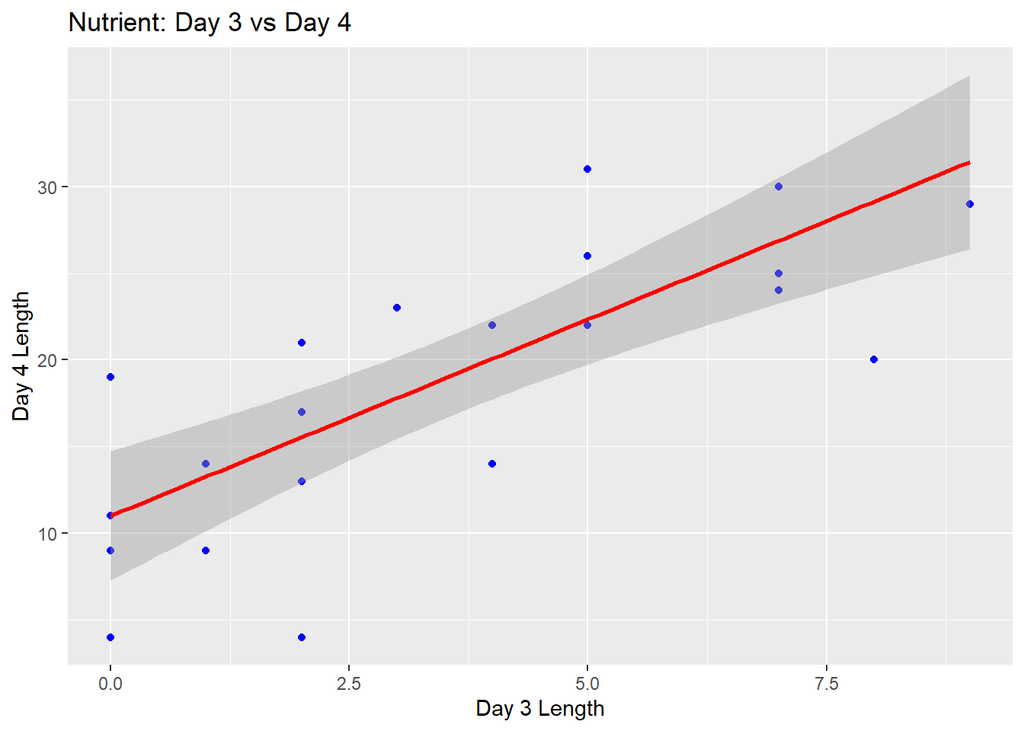

```r
# Nutrient Day 3 vs Day 4
ggplot(nutrient, aes(x = day3, y = day4)) +
  geom_point(color = "blue") +
  geom_smooth(method = "lm", color = "red") +
  labs(title = "Nutrient: Day 3 vs Day 4", x = "Day 3 Length", y = "Day 4 Length")
```

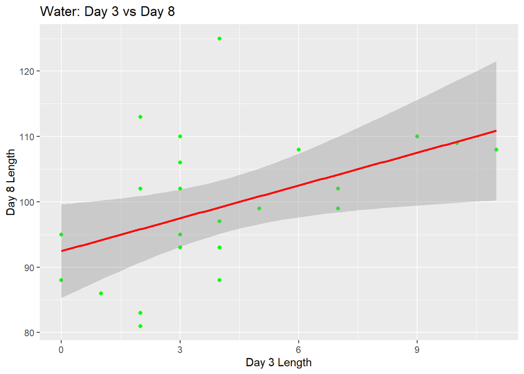

```r
# Water Day 3 vs Day 8
ggplot(water, aes(x = day3, y = day8)) +
  geom_point(color = "green") +
  geom_smooth(method = "lm", color = "red") +
  labs(title = "Water: Day 3 vs Day 8", x = "Day 3 Length", y = "Day 8 Length")
```

```r
getAnywhere("cor.test.default")
```

[output not shown]

[output cut: 112 more lines]

[output not shown]

```r
#查看cor.test背後的程式碼#函數是如何處理輸入數據的（例如是否有 NA 值、是否是數字型資料）。
#背後的公式和計算方法，像是相關係數公式、t 值的計算。
#它如何處理不同的相關性檢定方法（例如 Pearson, Spearman, Kendall）。
#如何產生 p 值和檢定結果。
```